# Chap12 section 2

Mijeong Kim

```r
library(tsibble)
library(tsibbledata)
library(tibble)
library(dplyr)
library(knitr)
library(ggplot2)
library(fpp3)
library(fpp2)
library(seasonal)
library(feasts)
```

## 12.2 Prophet 모델

**Prophet** 모델은 Facebook(Taylor & Letham, 2018)이 개발한 시계열 예측 모델로,  
`fable.prophet` 패키지를 통해 사용할 수 있다.  
원래는 **일별 자료의 주간·연간 계절성 및 공휴일 효과**를 반영하기 위해 설계되었으며,  
이후 다양한 유형의 계절성을 다룰 수 있도록 확장되었다.

이 모델은 **강한 계절성**과 **충분한 과거 관측치**가 있는 시계열에 가장 적합하다.

#### Prophet 모형 구조

Prophet은 다음과 같은 형태의 **비선형 회귀 모형**이다:

$$y_t = g(t) + s(t) + h(t) + \varepsilon_t$$

- $g(t)$: **piecewise-linear 추세(성장 함수)**, 변곡점은 자동 또는 수동 지정 가능
- $s(t)$: **계절성**, Fourier 항으로 표현됨 (기본적으로 연간 10차, 주간 3차)
- $h(t)$: **공휴일 효과**, 더미 변수로 반영
- $\varepsilon_t$: **백색잡음 오차**

#### 기타 특성

- 추세에 **로지스틱 함수**를 설정하면 **상한값(bound)**을 지정할 수 있음
- 모형은 **베이지안 접근**을 통해 추정되며,  
  이로 인해 **변곡점(changepoint)과 기타 모형 요소를 자동으로 선택**할 수 있다

#### 예시 데이터

Prophet 모델은 두 가지 사례로 설명된다: 1. 간단한 **분기별 시계열 자료** 2. 앞서 사용된 **전력 수요 데이터**

### Example: Quarterly cement production

간단한 분기별 예제에서는 **9.10절의 ARIMA 및 ETS 모델 비교 분석을 반복**하되, 여기에 **Prophet 모델을 추가하여 성능을 비교**한다.

```r
library(fable.prophet)
cement <- aus_production |>
  filter(year(Quarter) >= 1988)
train <- cement |>
  filter(year(Quarter) <= 2007)
fit <- train |>
  model(
    arima = ARIMA(Cement),
    ets = ETS(Cement),
    prophet = prophet(Cement ~ season(period = 4, order = 2,
                                    type = "multiplicative"))
  )
```

Prophet 모델에서는 **계절 주기(period)를 명확히 지정해야** 하며, 이는 기본 설정이 **일 단위 이상의 자료**를 가정하기 때문이다. 따라서 **분기별 또는 월별 자료**에는 **명시적으로 period를 설정**해야 한다.

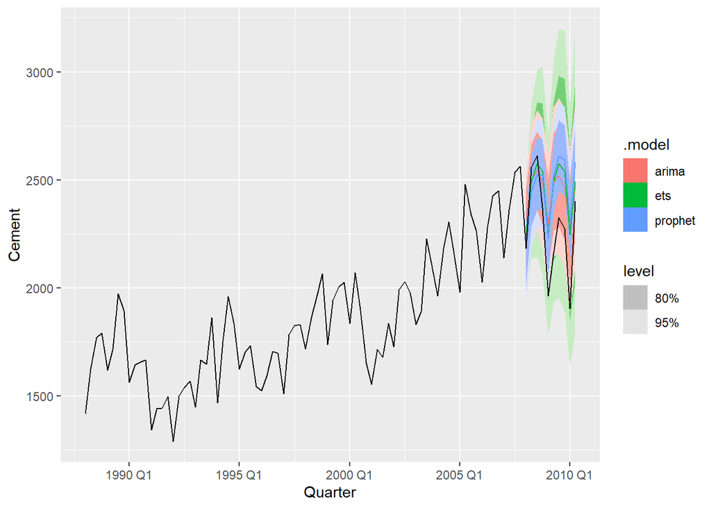

```r
fc <- fit |> forecast(h = "2 years 6 months")
fc |> autoplot(cement)
```

Figure 12.9: Prophet compared to ETS and ARIMA on the Cement production data, with a 10-quarter test set.

이 예제에서는 **Prophet 예측 성능이 ETS나 ARIMA보다 낮게 나타났다.**

```r
fc |> accuracy(cement)
```

```
## # A tibble: 3 × 10
##   .model  .type    ME  RMSE   MAE   MPE  MAPE  MASE RMSSE  ACF1
##   <chr>   <chr> <dbl> <dbl> <dbl> <dbl> <dbl> <dbl> <dbl> <dbl>
## 1 arima   Test  -161.  216.  186. -7.71  8.68  1.27  1.26 0.387
## 2 ets     Test  -171.  222.  191. -8.07  8.85  1.30  1.29 0.579
## 3 prophet Test  -176.  248.  216. -8.37  9.90  1.47  1.45 0.701
```

### Example: Half-hourly electricity demand

이번에는 이전 절의 동적 고조파 회귀(DHR) 모형과 유사한 구조를 Prophet 모델로 적합한다. 일별 또는 일 이하 자료의 경우 Prophet의 기본 주기 설정이 적절하므로, 문자열로 주기만 지정해주면 된다.

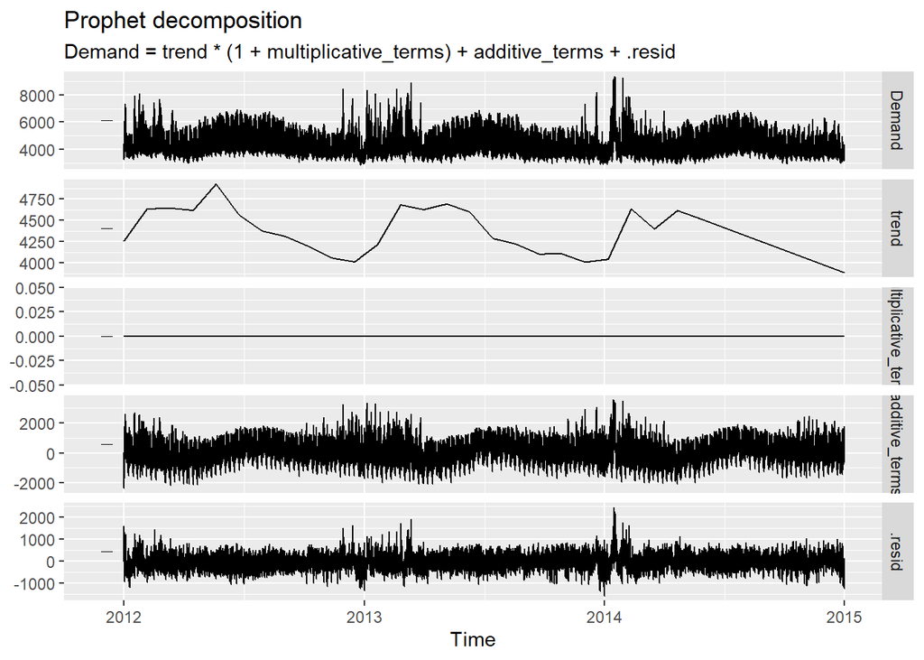

```r
elec <- vic_elec |>
  mutate(
    DOW = wday(Date, label = TRUE),
    Working_Day = !Holiday & !(DOW %in% c("Sat", "Sun")),
    Cooling = pmax(Temperature, 18)
  )

fit <- elec  |>
  model(
    prophet(Demand ~ Temperature + Cooling + Working_Day +
            season(period = "day", order = 10) +
            season(period = "week", order = 5) +
            season(period = "year", order = 3))
  )
fit |>
  components() |>
  autoplot()
```

Figure 12.10: Components of a Prophet model fitted to the Victorian electricity demand data.

이 Prophet 모형은 이전 절의 DHR 모형과 **유사한 구조**지만, 결과에는 몇 가지 **중요한 차이점**이 있다.

- Prophet은 **piecewise 선형 추세**를 추가하지만, 이 시계열에서는 **장기적으로 하락 추세가 지속될 것으로 보기 어려워 적절하지 않다**.
- 또한, **잔차에 상당한 자기상관이 남아 있어** 모형이 모든 구조를 충분히 설명하지 못했다.

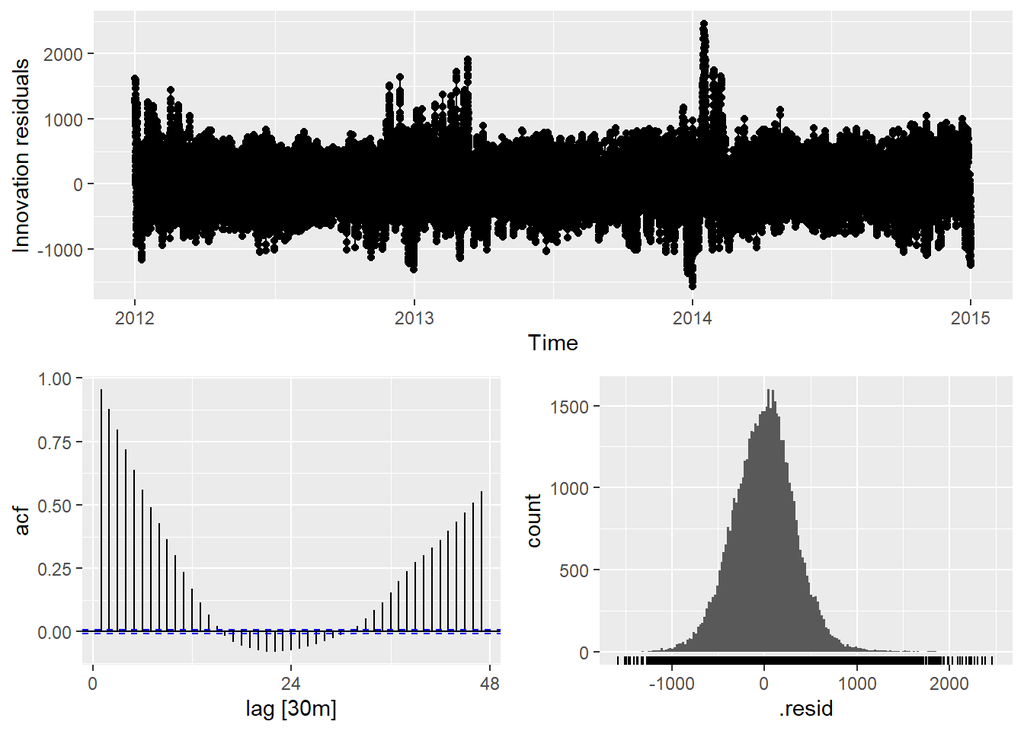

```r
fit |> gg_tsresiduals()
```

Figure 12.11: Residuals from the Prophet model for Victorian electricity demand.

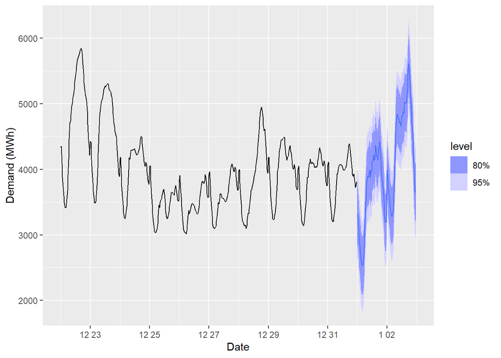

```r
elec_newdata <- new_data(elec, 2*48) |>
  mutate(
    Temperature = tail(elec$Temperature, 2 * 48),
    Date = lubridate::as_date(Time),
    DOW = wday(Date, label = TRUE),
    Working_Day = (Date != "2015-01-01") &
                   !(DOW %in% c("Sat", "Sun")),
    Cooling = pmax(Temperature, 18)
  )

fc <- fit |>
  forecast(new_data = elec_newdata)

fc |>
  autoplot(elec |> tail(10 * 48)) +
  labs(x = "Date", y = "Demand (MWh)")
```

Figure 12.12: Two day forecasts from the Prophet model for Victorian electricity demand.

**Prophet**은 **추정이 매우 빠르고 완전히 자동화되어 있다는 장점**이 있지만, 이전 예시들에서 보듯이 **예측 정확도는 다른 방법들보다 낮은 경우가 많다**.